# Coursera - Practical Machine Learning

Course Project

Thomas van Zyl

24 July 2016

## Background

Using devices such as Jawbone Up, Nike FuelBand, and Fitbit it is now possible to collect a large amount of data about personal activity relatively inexpensively. One thing that people regularly do is quantify how much of a particular activity they do, but they rarely quantify how well they do it. In this project, the goal is to use data from accelerometers on the belt, forearm, arm, and dumbbell to do predictions on the manner the exercise (dumbbell curl) is done. Six young health participants were asked to perform one set of 10 repetitions of the Unilateral Dumbbell Biceps Curl in five different fashions: exactly according to the specification (Class A), throwing the elbows to the front (Class B), lifting the dumbbell only halfway (Class C), lowering the dumbbell only halfway (Class D) and throwing the hips to the front (Class E).  
More information is available from the website here: http://groupware.les.inf.puc-rio.br/har (see the section on the Weight Lifting Exercise Dataset).

## Data

The training data for this project are available here: https://d396qusza40orc.cloudfront.net/predmachlearn/pml-training.csv  
The test data are available here: https://d396qusza40orc.cloudfront.net/predmachlearn/pml-testing.csv  
The data for this project come from this source: http://groupware.les.inf.puc-rio.br/har

## Load and Clean the Data

The data was downloaded from the above source to a local computer. A brief visual inspection showed lots of columns with “NA”" data as well as “#DIV/0!”. These columns are removed as part of the data cleaning. The identification variables can also be removed.

```r
set.seed(343248)
train_dataset <- "./pml-training.csv"
training_val <- read.csv(file=train_dataset, header=TRUE, sep=",", na.strings=c("NA","#DIV/0!",""))
test_dataset <- "./pml-testing.csv"
testing <- read.csv(file=test_dataset, header=TRUE, sep=",", na.strings=c("NA","#DIV/0!",""))
```

```r
dim(training_val)
```

```
## [1] 19622   160
```

```r
dim(testing)
```

```
## [1]  20 160
```

Split the training data into a training and validation set (the test set is reserved for the final testing).

```r
inTrain  <- createDataPartition(training_val$classe, p=0.75, list=FALSE)
training <- training_val[inTrain, ]
validation  <- training_val[-inTrain, ]
```

```r
dim(training)
```

```
## [1] 14718   160
```

```r
dim(validation)
```

```
## [1] 4904  160
```

```r
dim(testing)
```

```
## [1]  20 160
```

Remove the identification columns (like user_name, etc.)

```r
training <- training[, -(1:5)]
validation <- validation[, -(1:5)]
```

Remove columns with more than 90% NA values

```r
NA_Cols_9 <- sapply(training, function(x) mean(is.na(x))) > 0.9
training <- training[, NA_Cols_9==FALSE]
validation <- validation[, NA_Cols_9==FALSE]
```

```r
dim(training)
```

```
## [1] 14718    55
```

```r
dim(validation)
```

```
## [1] 4904   55
```

## Find Model

For this project 2 models will be evaluated, decision trees and “good old faithful” random forests.

### 1) Decision Tree

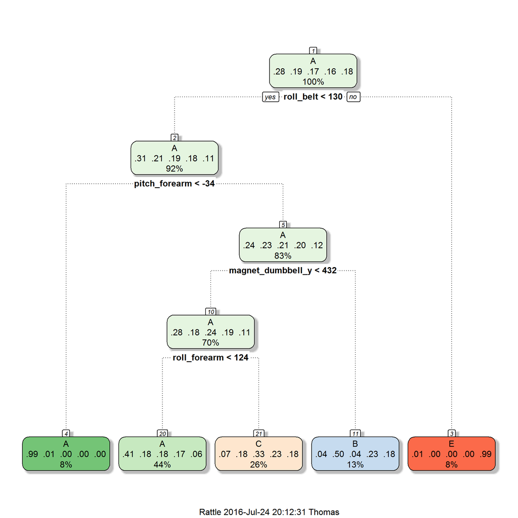

```r
mod_DecTree <- train(classe ~ ., method="rpart", data=training)
fancyRpartPlot(mod_DecTree$finalModel)
```

```r
predict_mod_DecTree <- predict(mod_DecTree,newdata = validation)
confMatrix_DecTree <- confusionMatrix(validation$classe, predict_mod_DecTree)
confMatrix_DecTree
```

```
## Confusion Matrix and Statistics
##
##           Reference
## Prediction    A    B    C    D    E
##          A 1257   27  107    0    4
##          B  399  330  220    0    0
##          C  405   27  423    0    0
##          D  363  143  298    0    0
##          E  118  138  243    0  402
##
## Overall Statistics
##
##                Accuracy : 0.4918
##                  95% CI : (0.4778, 0.5059)
##     No Information Rate : 0.5184
##     P-Value [Acc > NIR] : 0.9999
##
##                   Kappa : 0.3359
##  Mcnemar's Test P-Value : NA
##
## Statistics by Class:
##
##                      Class: A Class: B Class: C Class: D Class: E
## Sensitivity            0.4945  0.49624  0.32765       NA  0.99015
## Specificity            0.9416  0.85397  0.88043   0.8361  0.88906
## Pos Pred Value         0.9011  0.34773  0.49474       NA  0.44617
## Neg Pred Value         0.6338  0.91530  0.78563       NA  0.99900
## Prevalence             0.5184  0.13560  0.26325   0.0000  0.08279
## Detection Rate         0.2563  0.06729  0.08626   0.0000  0.08197
## Detection Prevalence   0.2845  0.19352  0.17435   0.1639  0.18373
## Balanced Accuracy      0.7180  0.67511  0.60404       NA  0.93960
```

The accuracy for the decision tree is: 0.4918434

### 2) Random Forests

```r
mod_RandForest <- train(classe ~ ., method="rf", data=training)
predict_mod_RandForest <- predict(mod_RandForest,newdata = validation)
confMatrix_RandForest <- confusionMatrix(validation$classe, predict_mod_RandForest)
confMatrix_RandForest
```

```
## Confusion Matrix and Statistics
##
##           Reference
## Prediction    A    B    C    D    E
##          A 1395    0    0    0    0
##          B    5  944    0    0    0
##          C    0    4  851    0    0
##          D    0    0    4  800    0
##          E    0    0    0    0  901
##
## Overall Statistics
##
##                Accuracy : 0.9973
##                  95% CI : (0.9955, 0.9986)
##     No Information Rate : 0.2855
##     P-Value [Acc > NIR] : < 2.2e-16
##
##                   Kappa : 0.9966
##  Mcnemar's Test P-Value : NA
##
## Statistics by Class:
##
##                      Class: A Class: B Class: C Class: D Class: E
## Sensitivity            0.9964   0.9958   0.9953   1.0000   1.0000
## Specificity            1.0000   0.9987   0.9990   0.9990   1.0000
## Pos Pred Value         1.0000   0.9947   0.9953   0.9950   1.0000
## Neg Pred Value         0.9986   0.9990   0.9990   1.0000   1.0000
## Prevalence             0.2855   0.1933   0.1743   0.1631   0.1837
## Detection Rate         0.2845   0.1925   0.1735   0.1631   0.1837
## Detection Prevalence   0.2845   0.1935   0.1743   0.1639   0.1837
## Balanced Accuracy      0.9982   0.9973   0.9972   0.9995   1.0000
```

The accuracy for random forest is: 0.9973491

## Final Prediction

The random forest model is the most accurate, we can now apply the model to the test data set.

```r
fin_predict <- predict(mod_RandForest, newdata=testing)
fin_predict
```

```
##  [1] B A B A A E D B A A B C B A E E A B B B
## Levels: A B C D E
```

This concludes the course project.